# Visualization of in-text table summaries

Laure Cougnaud

May 04, 2026

This vignette focuses on the visualization functionalities available within the `inTextSummaryTable` package.

If you need to see figures bigger, just click on a graphic, and it will pop up more readable.

Summary statistics can be visualized by:

1. **extracting the summary statistics table** with the `computeSummaryStatisticsTable` function (used for `getSummaryStatistics` function)
2. **visualizing the summary statistics via the `subjectProfileSummaryPlot`** function

By default the **`subjectProfileSummaryPlot`** plots the mean values with **error bars** based on standard errors.

Moreover, the `subjectProfileSummaryPlot` allows the possibility to add a table of counts of the number of subject for a specific combination of variables.

This vignette will guide the user to

- default **visualizations for A4 and presentation documents**
- **customize palettes of colors, shape, linetypes**
- **visualization with and without table of counts and by facets**
- general customizable input

However, in order to get a full overview of the functionalities the documentation is available in the console with `? subjectProfileSummaryPlot`.

We will first create example data sets to show how the exporting functionalities work. The data sets used here are available in the `clinUtils` package.

# 1 Load packages and data

```r
library(inTextSummaryTable)
library(clinUtils)
```

```r
# load example data
data(dataADaMCDISCP01)

dataAll <- dataADaMCDISCP01
labelVars <- attr(dataAll, "labelVars")
```

# 2 Compute summary statistics

Below we compute summary statistics for the laboratory data set.

```r
dataLB <- subset(dataAll$ADLBC, grepl("Baseline|Week", AVISIT))
dataLB$AVISIT <- with(dataLB, reorder(trimws(AVISIT), AVISITN))
dataLB$TRTA <- with(dataLB, reorder(TRTA, TRTAN))

summaryTableDf <- computeSummaryStatisticsTable(
    data = dataLB,
    var = "AVAL",
    rowVar = c("PARCAT1", "PARAM"),
    colVar = c("TRTA", "AVISIT")
)
```

# 3 Visualization for A4 document

The code below shows the default visualization, which plots the **mean with standard errors** **suitable for an A4 document**, e.g. Word/pdf.

Note that the table below the plot is based on the counts for treatment and visit variables, as specificed in the `colVar` argument of the code chuck above for `computeSummaryStatisticsTable`.

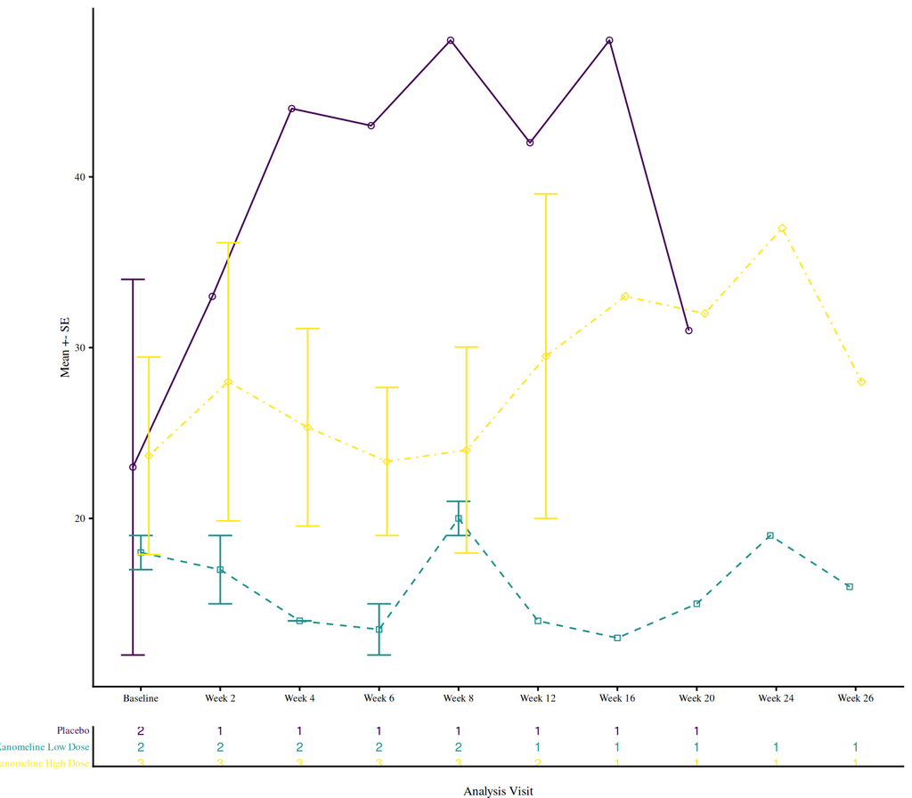

```r
# create the plot
dataPlot <- subset(
    summaryTableDf,
    !isTotal &
     PARAM == "Alanine Aminotransferase (U/L)"
)

subjectProfileSummaryPlot(
    data = dataPlot,
    xVar = "AVISIT",
    colorVar = "TRTA",
    labelVars = labelVars,
    useLinetype = TRUE,
    tableText = "statN"
)
```

# 4 Visualization for presentation

The code below shows the default visualization **suitable for a presentation**, either in Powerpoint or ioslides.

```r
# 'Tahoma' font should be registered upfront to create plots with: 'presentation' style
subjectProfileSummaryPlot(
    data = dataPlot,
    xVar = "AVISIT",
    colorVar = "TRTA",
    labelVars = labelVars,
    useLinetype = TRUE,
    tableText = "statN",
    style = "presentation"
)
```

[output not shown]

Please note that the default font for presentation is *Tahoma*.

If you don’t have this default font available, the R package [*extrafont*](https://cran.r-project.org/package=extrafont) might be useful to register fonts with your R graphics device.

# 5 Palettes

The `inTextSummaryTable` uses default palettes available in the `clinUtils` package.

However, palettes are fully customizable. Currently, there are two alternative approaches to change the defaults:

- set the custom palettes as arguments in the `subjectProfileSummaryPlot` via the dedicated parameters **`colorPalette`**, **`shapePalette`**, **`linetypePalette`**
- set the **global options** into the R session.

Passing input arguments to the function might be convenient when creating one plot.

Instead, **passing the global options is very handy when creating multiple graphics**, so that the palettes have to be set only once at the beginning of the R script, without the need to copy-paste input arguments in the different visualizations.

If you want to **know more about aesthetics options of the `inTextSummaryTable`**, see the vignette: Customization of aesthetics of in-text tables

If you want to **know more about default options from the `clinUtils`**, you may check out the vignette of the package:

```r
vignette("clinUtils-vignette", "clinUtils")
```

Sections below show below both alternative approaches for setting the palettes.

## 5.1 Custom palettes via arguments in the function

In this section we guide on how to set custom palettes via the `subjectProfileSummaryPlot` function.

### 5.1.1 Color palette

This section focuses on the possibility to set the `colorPalette` argument.

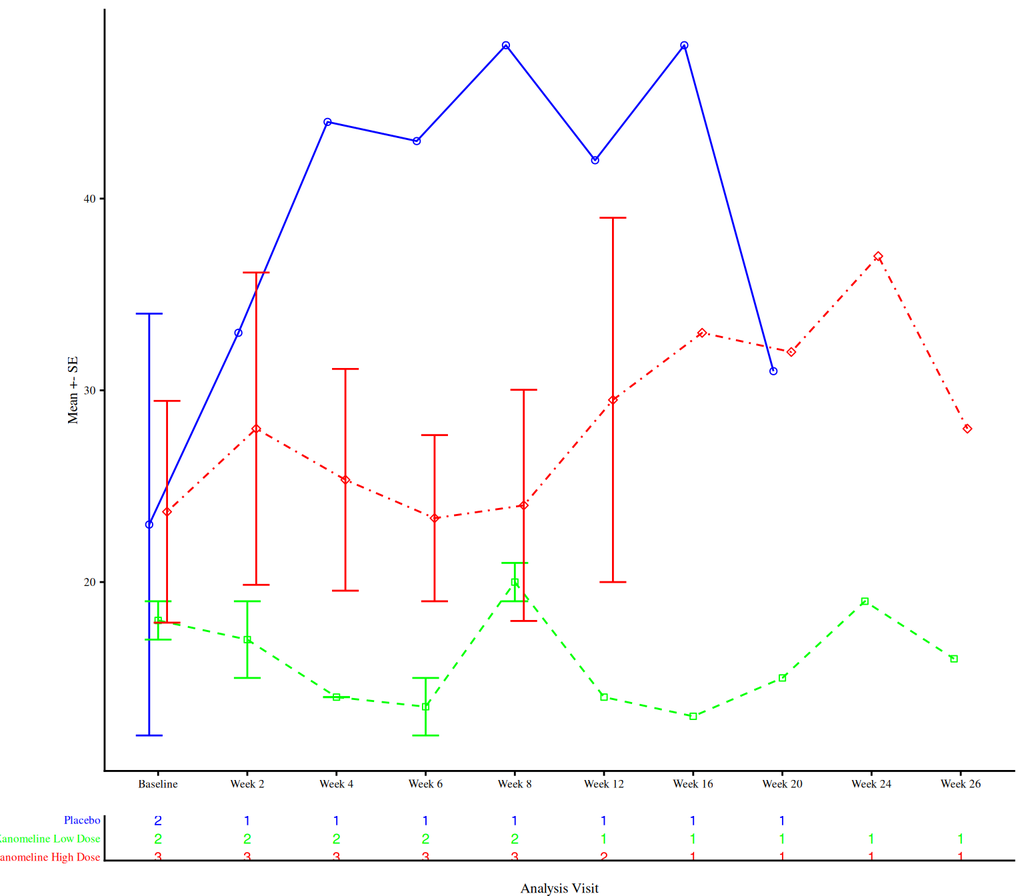

```r
# custom color palette by setting a named vector of colors
customColorPalette <- c(
    `Xanomeline Low Dose` = "green",
    `Xanomeline High Dose` = "red",
    `Placebo` = "blue"
)
subjectProfileSummaryPlot(
    data = dataPlot,
    xVar = "AVISIT",
    colorVar = "TRTA",
    colorPalette = customColorPalette,
    labelVars = labelVars,
    useLinetype = TRUE,
    tableText = "statN"
)
```

### 5.1.2 Shape and linetype palettes

This section focuses on the possibility to set the `shapePalette` and `linetypePalette` arguments.

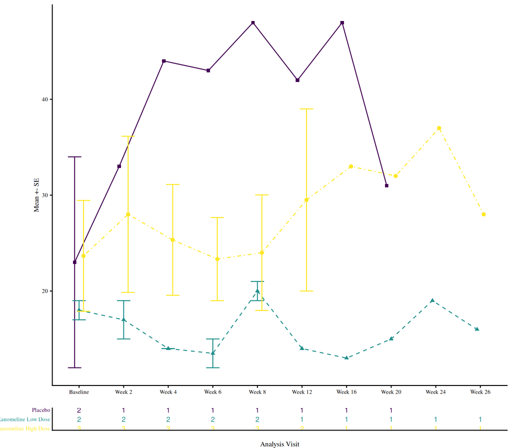

```r
# custom shape palette
customShapePalette <- c(15, 17, 19)
subjectProfileSummaryPlot(
    data = dataPlot,
    xVar = "AVISIT",
    colorVar = "TRTA",
    shapePalette = customShapePalette,
    labelVars = labelVars,
    useLinetype = TRUE,
    tableText = "statN"
)
```

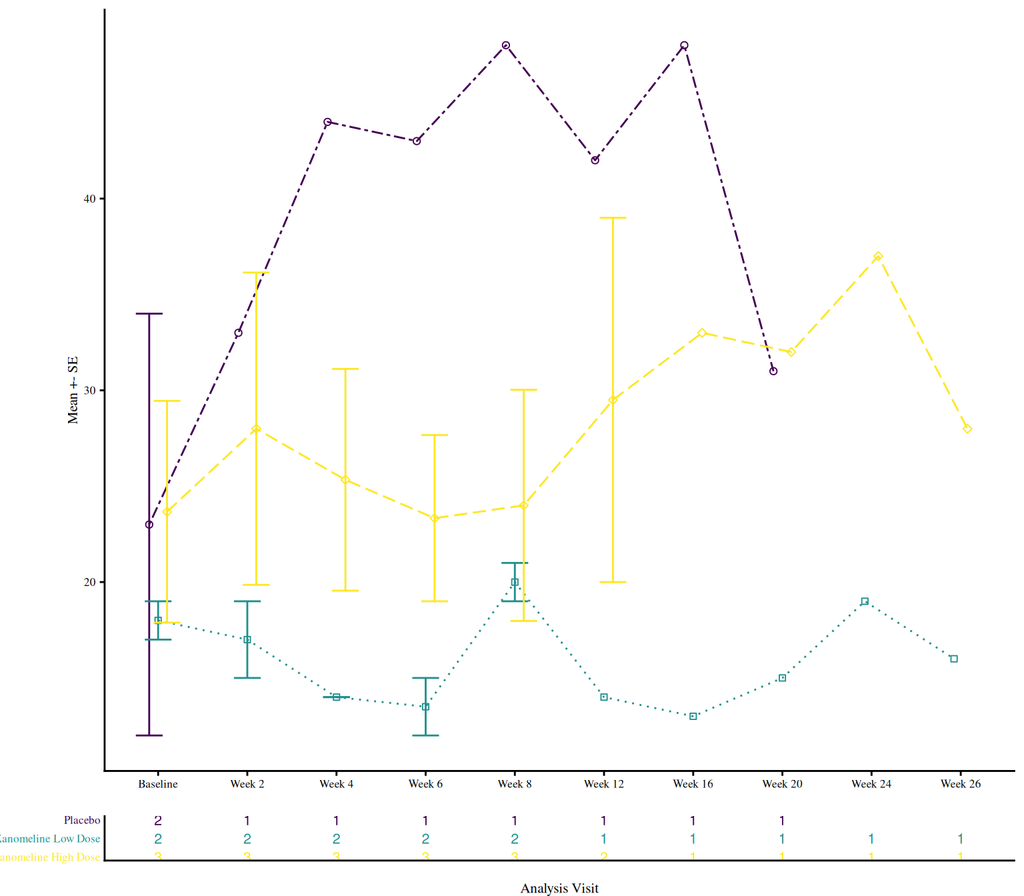

```r
# custom linetype palette
customLinetypePalette <- c("twodash", "dotted", "longdash")
subjectProfileSummaryPlot(
    data = dataPlot,
    xVar = "AVISIT",
    colorVar = "TRTA",
    linetypePalette = customLinetypePalette,
    labelVars = labelVars,
    useLinetype = TRUE,
    tableText = "statN"
)
```

## 5.2 Custom palettes via setting global options

The `inTextSummaryTable` package allows the user to define global options in the R session.

As mentioned above, setting the global options is convenient because the palettes have to be set only once in the R script or Rmd document.

Please note that the global options have to be set **after** loading the package. This because when loading the package, the default global options for palettes will overwrite the custom palettes.

Here in practice:

```r
# this is OK
library(inTextSummaryTable)
options(inTextSummaryTable.colors.plot = customColorPalette)

# this does NOT set your custom palette
options(inTextSummaryTable.colors.plot = customColorPalette)
library(inTextSummaryTable)
```

### 5.2.1 Coloring palettes

Color palettes can be set up with the `inTextSummaryTable.colors.plot` option.

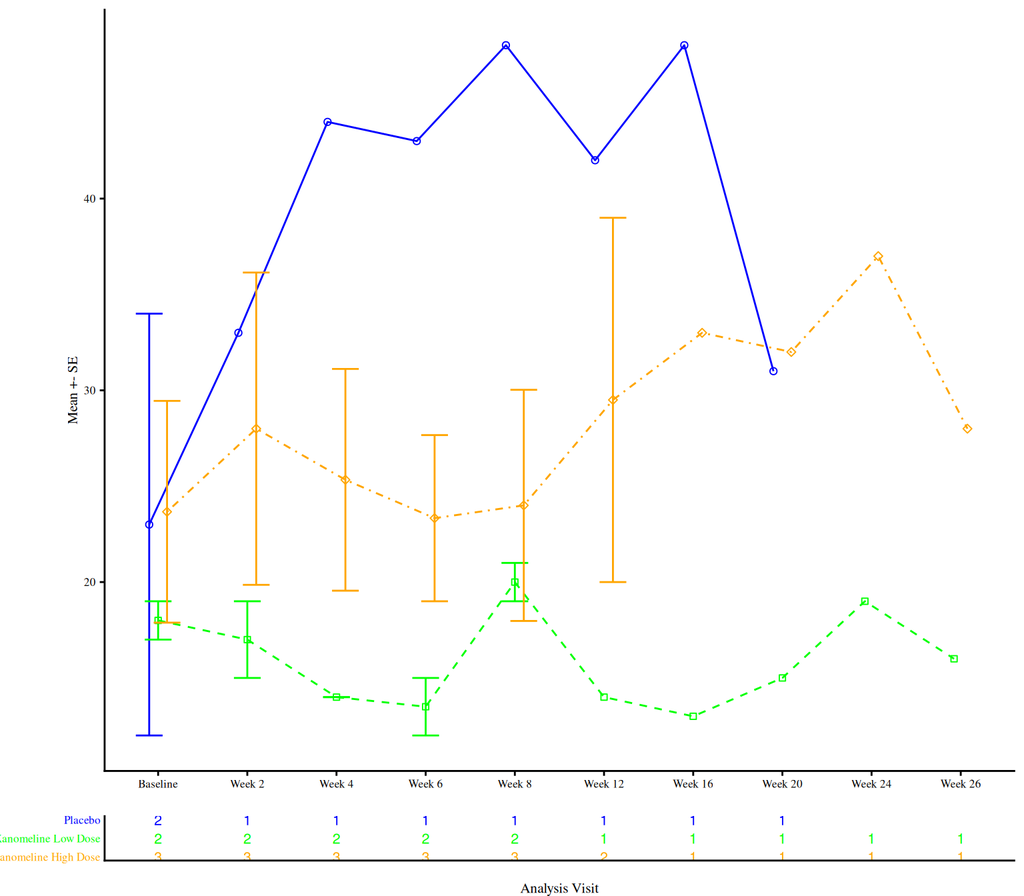

```r
# custom color palette by setting a simple vector of colors
customColorPalette <- c("blue", "green", "orange")
options(inTextSummaryTable.colors.plot = customColorPalette)

subjectProfileSummaryPlot(
    data = dataPlot,
    xVar = "AVISIT",
    colorVar = "TRTA",
    labelVars = labelVars,
    useLinetype = TRUE,
    tableText = "statN"
)
```

[figure not shown]

```r
# custom color palette by setting a named vector of colors
customColorPalette <- c(
    `Xanomeline Low Dose` = "green",
    `Xanomeline High Dose` = "red",
    `Placebo` = "purple"
)
options(inTextSummaryTable.colors.plot = customColorPalette)

subjectProfileSummaryPlot(
    data = dataPlot,
    xVar = "AVISIT",
    colorVar = "TRTA",
    labelVars = labelVars,
    useLinetype = TRUE,
    tableText = "statN"
)
```

### 5.2.2 Shape and linetype palettes

What shown for the color palette is consistent for shape and linetypes palettes. In this case, the global options are called `inTextSummaryTable.shapes.plot` and `inTextSummaryTable.linetypes.plot`.

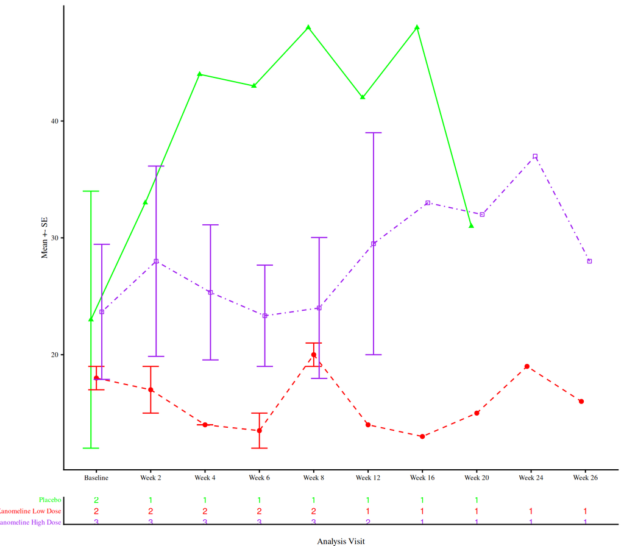

```r
# custom shape palette
customShapePalette <- c(17, 19, 22)
options(inTextSummaryTable.shapes.plot = customShapePalette)

subjectProfileSummaryPlot(
    data = dataPlot,
    xVar = "AVISIT",
    colorVar = "TRTA",
    labelVars = labelVars,
    useLinetype = TRUE,
    tableText = "statN"
)
```

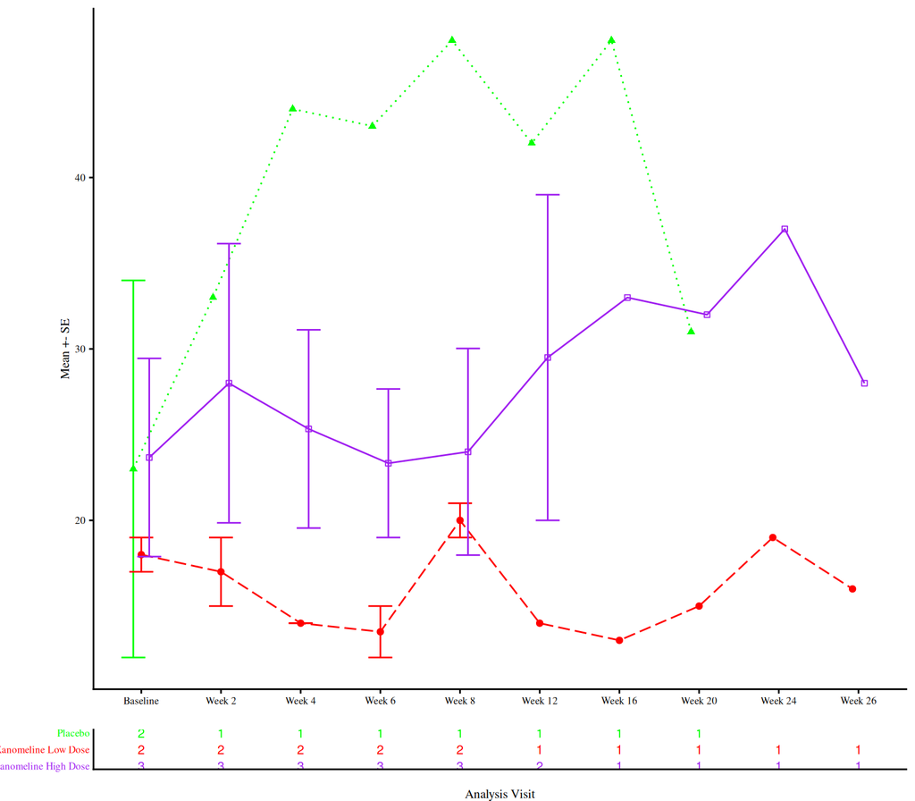

```r
# custom linetype palette
customLinetypePalette <- c("dotted", "longdash", "solid")
options(inTextSummaryTable.linetypes.plot = customLinetypePalette)

subjectProfileSummaryPlot(
    data = dataPlot,
    xVar = "AVISIT",
    colorVar = "TRTA",
    labelVars = labelVars,
    useLinetype = TRUE,
    tableText = "statN"
)
```

## 5.3 Set back default palettes

There is always to possibility to switch back to the default palettes of the package:

```r
options(inTextSummaryTable.colors.plot = clinColors)
options(inTextSummaryTable.shapes.plot = clinShapes)
options(inTextSummaryTable.linetypes.plot = clinLinetypes)
```

# 6 Visualization without count table

The user can decide to remove the table of counts by setting the parameter **`tableText`** to `NULL`, as the code below shows.

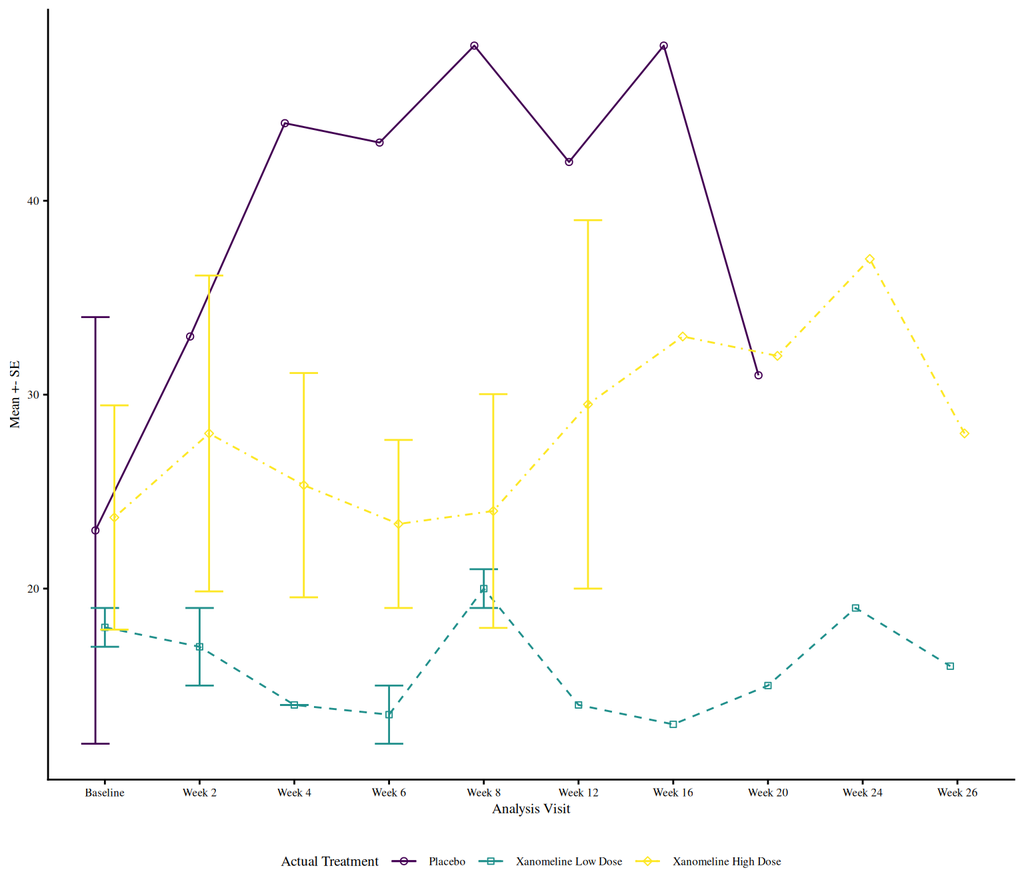

```r
subjectProfileSummaryPlot(
    data = dataPlot,
    xVar = "AVISIT",
    colorVar = "TRTA",
    labelVars = labelVars,
    useLinetype = TRUE,
    tableText = NULL
)
```

# 7 Visualization by facets

It is possible to directly plot multiple parameters with the **`facetVar`** argument.

Please note that setting the `facetVar` is not compatible with adding a table of counts underneath the plot.

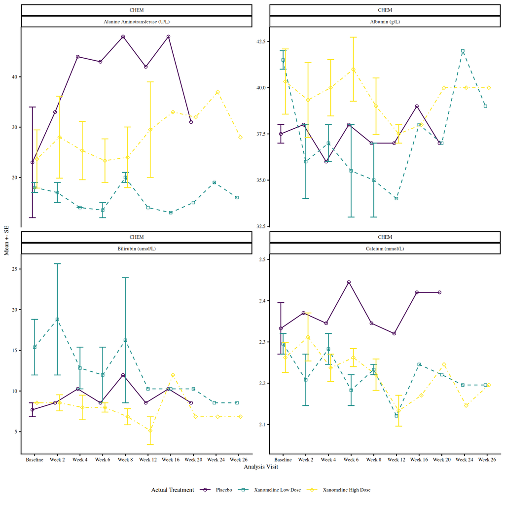

```r
# create the plot
dataPlotFacets <- subset(
    summaryTableDf,
    !isTotal &
        PARAM %in% c(
            "Alanine Aminotransferase (U/L)",
            "Albumin (g/L)",
            "Bilirubin (umol/L)",
            "Calcium (mmol/L)"
        )
)

subjectProfileSummaryPlot(
    data = dataPlotFacets,
    xVar = "AVISIT",
    colorVar = "TRTA",
    labelVars = labelVars,
    facetVar = c("PARCAT1", "PARAM"),
    useLinetype = TRUE
)
```

# 8 Customize your visualization

The `subjectProfileSummaryPlot` has many options! A non-exaustive demonstration is presented below.

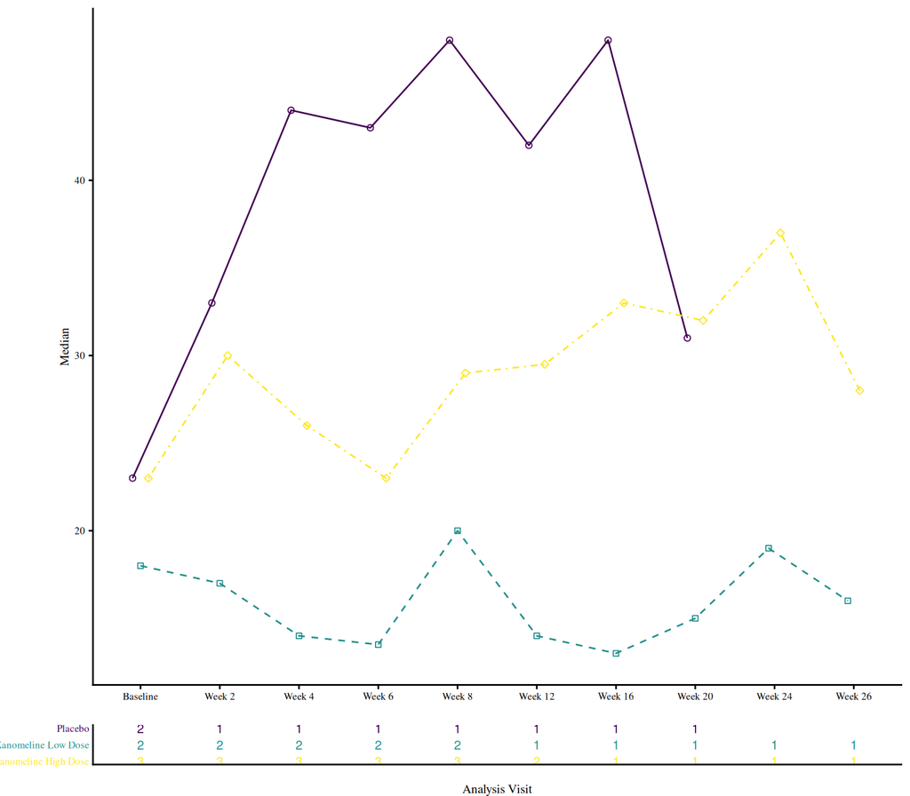

```r
# plot the median instead of mean
# no error bars
subjectProfileSummaryPlot(
    data = dataPlot,
    xVar = "AVISIT",
    meanVar = "statMedian",
    seVar = NULL,
    colorVar = "TRTA",
    labelVars = labelVars,
    useLinetype = TRUE,
    tableText = "statN"
)
```

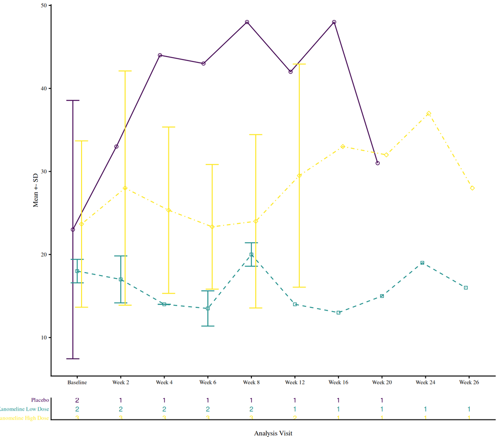

```r
# plot the mean with standard deviation
subjectProfileSummaryPlot(
    data = dataPlot,
    xVar = "AVISIT",
    seVar = "statSD",
    colorVar = "TRTA",
    labelVars = labelVars,
    useLinetype = TRUE,
    tableText = "statN"
)
```

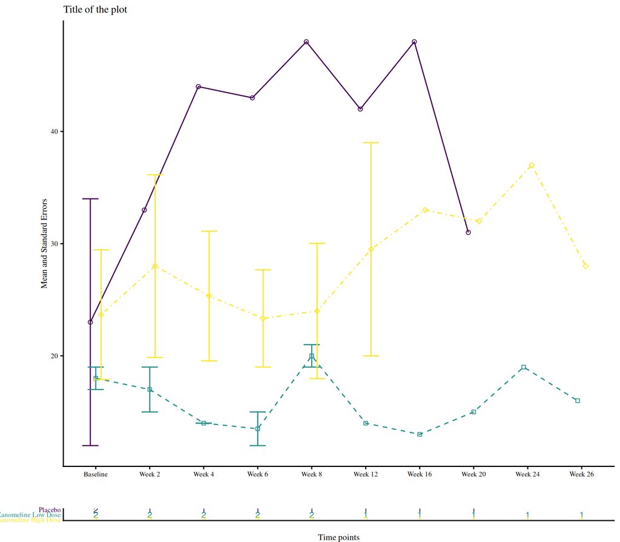

```r
# change labels
subjectProfileSummaryPlot(
    data = dataPlot,
    xVar = "AVISIT",
    xLab = "Time points",
    yLab = "Mean and Standard Errors",
    title = "Title of the plot",
    colorVar = "TRTA",
    labelVars = labelVars,
    useLinetype = TRUE,
    tableText = "statN"
)
```

# 9 Appendix

## 9.1 Session information

R version 4.6.0 (2026-04-24) Platform: x86_64-pc-linux-gnu Running under: Ubuntu 24.04.4 LTS

Matrix products: default BLAS: /usr/lib/x86_64-linux-gnu/openblas-pthread/libblas.so.3 LAPACK: /usr/lib/x86_64-linux-gnu/openblas-pthread/libopenblasp-r0.3.26.so; LAPACK version 3.12.0

locale: [1] LC_CTYPE=en_US.UTF-8 LC_NUMERIC=C LC_TIME=en_US.UTF-8 LC_COLLATE=C LC_MONETARY=en_US.UTF-8 LC_MESSAGES=en_US.UTF-8  
[7] LC_PAPER=en_US.UTF-8 LC_NAME=C LC_ADDRESS=C LC_TELEPHONE=C LC_MEASUREMENT=en_US.UTF-8 LC_IDENTIFICATION=C

time zone: Etc/UTC tzcode source: system (glibc)

attached base packages: [1] tools stats graphics grDevices utils datasets methods base

other attached packages: [1] plyr_1.8.9 clinUtils_0.2.2 inTextSummaryTable_3.4.0 knitr_1.51

loaded via a namespace (and not attached): [1] gtable_0.3.6 xfun_0.57 bslib_0.10.0 ggplot2_4.0.3 htmlwidgets_1.6.4 ggrepel_0.9.8  
[7] vctrs_0.7.3 crosstalk_1.2.2 generics_0.1.4 tibble_3.3.1 pkgconfig_2.0.3 data.table_1.18.2.1  
[13] RColorBrewer_1.1-3 S7_0.2.2 uuid_1.2-2 lifecycle_1.0.5 flextable_0.9.11 compiler_4.6.0  
[19] farver_2.1.2 stringr_1.6.0 textshaping_1.0.5 fontquiver_0.2.1 fontLiberation_0.1.0 htmltools_0.5.9  
[25] sass_0.4.10 yaml_2.3.12 Rttf2pt1_1.3.14 extrafontdb_1.1 pillar_1.11.1 jquerylib_0.1.4  
[31] tidyr_1.3.2 openssl_2.4.0 DT_0.34.0 cachem_1.1.0 fontBitstreamVera_0.1.1 tidyselect_1.2.1  
[37] zip_2.3.3 digest_0.6.39 stringi_1.8.7 dplyr_1.2.1 reshape2_1.4.5 purrr_1.2.2  
[43] labeling_0.4.3 forcats_1.0.1 extrafont_0.20 cowplot_1.2.0 fastmap_1.2.0 grid_4.6.0  
[49] cli_3.6.6 magrittr_2.0.5 withr_3.0.2 gdtools_0.5.0 scales_1.4.0 rmarkdown_2.31  
[55] officer_0.7.4 otel_0.2.0 askpass_1.2.1 ragg_1.5.2 hms_1.1.4 evaluate_1.0.5  
[61] haven_2.5.5 viridisLite_0.4.3 rlang_1.2.0 Rcpp_1.1.1-1.1 glue_1.8.1 xml2_1.5.2  
[67] jsonlite_2.0.0 R6_2.6.1 systemfonts_1.3.2